# 🧠 TP Deep Learning — Reconnaissance de Chiffres Manuscrits (MNIST)

**Objectif général :** Construire et analyser des réseaux de neurones pour la classification multi-classes,  
en progressant du **Perceptron simple** jusqu'au **MLP multicouches**, sur le dataset MNIST.

| Partie | Contenu |
| --- | --- |
| 1 | Chargement et exploration des données |
| 2 | Prétraitement |
| 3 | Encodage One-Hot |
| 4 | Perceptron multiclasses |
| 5 | Analyse de l'apprentissage |
| 6 | Validation et visualisation |
| 7 | Grid Search des hyperparamètres |
| 8 | Sauvegarde et chargement du modèle |
| 9 | MLP 1 couche cachée |
| 10 | MLP 2 couches cachées |
| Q1 | Impact des hyperparamètres |
| Q2 | Régularisation (Dropout & L2) |

> **Framework :** TensorFlow / Keras  
> **Dataset :** MNIST — 70 000 images 28×28 en niveaux de gris, 10 classes (chiffres 0–9)

```python
# =============================================================================
# IMPORTS GLOBAUX
# Centraliser tous les imports en début de notebook est une bonne pratique :
# cela évite les dépendances cachées et facilite la maintenance du code.
# =============================================================================

import numpy as np
import matplotlib.pyplot as plt
import time
import warnings
warnings.filterwarnings('ignore')

# TensorFlow / Keras
import tensorflow as tf
from tensorflow.keras.datasets import mnist
from tensorflow.keras.models import Sequential, load_model
from tensorflow.keras.layers import Dense, Dropout
from tensorflow.keras.optimizers import SGD
from tensorflow.keras.utils import to_categorical
from tensorflow.keras.regularizers import l2

# Scikit-learn
from sklearn.model_selection import GridSearchCV
from scikeras.wrappers import KerasClassifier   # pip install scikeras

# Reproductibilité : fixer les seeds garantit des résultats identiques
# à chaque exécution — indispensable en recherche et en production.
SEED = 42
np.random.seed(SEED)
tf.random.set_seed(SEED)

print(f'TensorFlow version : {tf.__version__}')
print('Imports OK ✅')
```

```
TensorFlow version : 2.21.0
Imports OK ✅
```

## Partie 1 — Chargement et Exploration des Données

> **Objectif :** Comprendre la structure du dataset avant toute modélisation.  
> En Data Science, explorer les données (*EDA*) est une étape non-négociable :  
> elle révèle les anomalies, la distribution des classes, et oriente les choix de preprocessing.

```python
# =============================================================================
# PARTIE 1 — Chargement et exploration des données MNIST
# =============================================================================

# -----------------------------------------------------------------------------
# 1. Chargement du dataset
# Keras télécharge MNIST automatiquement (~11 Mo) et le met en cache local.
# Le split 60k/10k est le split officiel du benchmark — on ne le modifie pas.
# -----------------------------------------------------------------------------
(x_train, y_train), (x_test, y_test) = mnist.load_data()

# -----------------------------------------------------------------------------
# 2. Exploration de la structure
# Vérifier systématiquement : shape, dtype, plage de valeurs.
# Un dtype uint8 et des valeurs 0-255 confirment des images brutes non normalisées.
# -----------------------------------------------------------------------------
print('=' * 50)
print('       STRUCTURE DU DATASET MNIST')
print('=' * 50)
print(f'  Images entraînement : {x_train.shape[0]:>6,}')
print(f'  Images test         : {x_test.shape[0]:>6,}')
print(f'  Taille image        : {x_train.shape[1]} × {x_train.shape[2]} pixels')
print(f'  Nombre de classes   : {len(np.unique(y_train))}')
print(f'  Type des pixels     : {x_train.dtype}')
print(f'  Valeurs min / max   : {x_train.min()} / {x_train.max()}')
print('=' * 50)

# -----------------------------------------------------------------------------
# 3. Distribution des classes
# Un dataset déséquilibré (class imbalance) biaiserait l'accuracy comme métrique.
# Sur MNIST, les classes sont quasiment équilibrées (~6 000 exemples par classe).
# -----------------------------------------------------------------------------
print('\nDistribution des classes (y_train) :')
unique, counts = np.unique(y_train, return_counts=True)
for cls, cnt in zip(unique, counts):
    barre = '█' * (cnt // 200)
    print(f'  Classe {cls} : {cnt:>5,}  {barre}')

# -----------------------------------------------------------------------------
# 4. Premières étiquettes
# -----------------------------------------------------------------------------
print(f'\nPremières étiquettes y_train : {y_train[:20]}')
```

```
Downloading data from https://storage.googleapis.com/tensorflow/tf-keras-datasets/mnist.npz
11490434/11490434 ━━━━━━━━━━━━━━━━━━━━ 1s 0us/step
==================================================
       STRUCTURE DU DATASET MNIST
==================================================
  Images entraînement : 60,000
  Images test         : 10,000
  Taille image        : 28 × 28 pixels
  Nombre de classes   : 10
  Type des pixels     : uint8
  Valeurs min / max   : 0 / 255
==================================================

Distribution des classes (y_train) :
  Classe 0 : 5,923  █████████████████████████████
  Classe 1 : 6,742  █████████████████████████████████
  Classe 2 : 5,958  █████████████████████████████
  Classe 3 : 6,131  ██████████████████████████████
  Classe 4 : 5,842  █████████████████████████████
  Classe 5 : 5,421  ███████████████████████████
  Classe 6 : 5,918  █████████████████████████████
  Classe 7 : 6,265  ███████████████████████████████
  Classe 8 : 5,851  █████████████████████████████
  Classe 9 : 5,949  █████████████████████████████

Premières étiquettes y_train : [5 0 4 1 9 2 1 3 1 4 3 5 3 6 1 7 2 8 6 9]
```

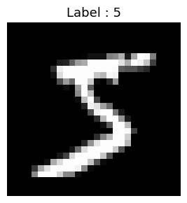

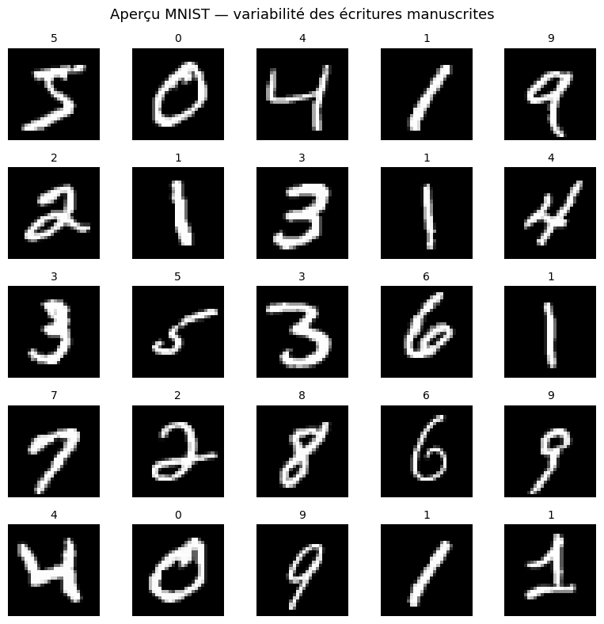

```python
# =============================================================================
# PARTIE 1 — Visualisation
# =============================================================================

# -----------------------------------------------------------------------------
# 4a. Visualisation d'une image isolée
# cmap='gray' est essentiel : sans lui, matplotlib appliquerait
# une palette de couleurs (viridis) sur des données en niveaux de gris.
# -----------------------------------------------------------------------------
plt.figure(figsize=(3, 3))
plt.imshow(x_train[0], cmap='gray')
plt.title(f'Label : {y_train[0]}', fontsize=13)
plt.axis('off')
plt.tight_layout()
plt.show()

# -----------------------------------------------------------------------------
# 4b. Grille 5×5 — aperçu de la variabilité des écritures
# Cette visualisation est cruciale : elle montre la diversité stylistique
# que le modèle devra apprendre à généraliser.
# -----------------------------------------------------------------------------
fig, axes = plt.subplots(5, 5, figsize=(8, 8))
fig.suptitle("Aperçu MNIST — variabilité des écritures manuscrites", fontsize=13)

for i, ax in enumerate(axes.flatten()):
    ax.imshow(x_train[i], cmap='gray')
    ax.set_title(str(y_train[i]), fontsize=10)
    ax.axis('off')

plt.tight_layout()
plt.show()
```

## Partie 2 — Prétraitement des Données

> **Objectif :** Transformer les images brutes en tenseurs exploitables par un réseau Dense.  
> Le preprocessing est souvent la clé de la performance : un modèle simple sur des données  
> bien préparées surpasse souvent un modèle complexe sur des données brutes.

```python
# =============================================================================
# PARTIE 2 — Prétraitement des données
# =============================================================================

# -----------------------------------------------------------------------------
# 1. Reshape : 28×28 → vecteur 784
# Les couches Dense (fully connected) attendent un vecteur 1D en entrée.
# reshape(-1, 784) : le -1 laisse NumPy inférer la dimension batch automatiquement.
# Note : pour un CNN, on garderait la forme (28, 28, 1) — pas besoin de flatten.
# -----------------------------------------------------------------------------
x_train_flat = x_train.reshape(-1, 784)
x_test_flat  = x_test.reshape(-1, 784)

# -----------------------------------------------------------------------------
# 2. Conversion en float32
# Les gradients sont calculés en virgule flottante.
# float32 est le standard GPU : 4x moins de mémoire que float64, même précision
# pour les besoins du deep learning.
# -----------------------------------------------------------------------------
x_train_flat = x_train_flat.astype('float32')
x_test_flat  = x_test_flat.astype('float32')

# -----------------------------------------------------------------------------
# 3. Normalisation Min-Max → [0, 1]
# Diviser par 255 (valeur max d'un pixel uint8).
# Avantages :
#   - Les poids initiaux (autour de 0) sont à la même échelle que les inputs
#   - La descente de gradient converge beaucoup plus vite
#   - Évite les problèmes numériques (overflow/underflow)
# Alternative avancée : normalisation Z-score (mean=0, std=1) — utile si
# la distribution des pixels est très asymétrique.
# -----------------------------------------------------------------------------
x_train_flat = x_train_flat / 255.0
x_test_flat  = x_test_flat  / 255.0

# -----------------------------------------------------------------------------
# 4. Vérification — ne jamais skip cette étape !
# Vérifier shape, dtype ET plage de valeurs avant de passer à la suite.
# -----------------------------------------------------------------------------
print('=== Vérification après prétraitement ===')
print(f'x_train : {x_train_flat.shape}  |  dtype : {x_train_flat.dtype}')
print(f'x_test  : {x_test_flat.shape}   |  dtype : {x_test_flat.dtype}')
print(f'Plage   : [{x_train_flat.min():.1f}, {x_train_flat.max():.1f}]  ✅ normalisé')

# Résumé de la transformation
print('\nTransformation :')
print(f'  (28, 28) uint8  →  (784,) float32  →  valeurs ÷ 255')
```

```
=== Vérification après prétraitement ===
x_train : (60000, 784)  |  dtype : float32
x_test  : (10000, 784)   |  dtype : float32
Plage   : [0.0, 1.0]  ✅ normalisé

Transformation :
  (28, 28) uint8  →  (784,) float32  →  valeurs ÷ 255
```

## Partie 3 — Encodage One-Hot des Labels

> **Objectif :** Transformer les labels entiers en vecteurs binaires compatibles avec Softmax.  
> Sans One-Hot, le modèle interpréterait les classes comme ordonnées (classe 9 > classe 1),  
> ce qui introduirait un biais sémantique inexistant dans le problème réel.

```python
# =============================================================================
# PARTIE 3 — Encodage One-Hot (OHE)
# =============================================================================

# -----------------------------------------------------------------------------
# 1. Transformation One-Hot
# to_categorical crée une matrice identité partielle :
# label 5 → [0, 0, 0, 0, 0, 1, 0, 0, 0, 0]
# C'est la représentation que Softmax + categorical_crossentropy attendent.
# num_classes=10 est explicite pour éviter les bugs si y_test ne contient
# pas toutes les classes.
# -----------------------------------------------------------------------------
y_train_ohe = to_categorical(y_train, num_classes=10)
y_test_ohe  = to_categorical(y_test,  num_classes=10)

# -----------------------------------------------------------------------------
# 2. Vérification des dimensions
# (60000,) → (60000, 10) : chaque label devient un vecteur de 10 classes
# -----------------------------------------------------------------------------
print('=== Vérification One-Hot Encoding ===')
print(f'y_train  avant OHE : {y_train.shape}       → après : {y_train_ohe.shape}')
print(f'y_test   avant OHE : {y_test.shape}        → après : {y_test_ohe.shape}')
print(f'Type     : {y_train_ohe.dtype}')

# -----------------------------------------------------------------------------
# 3. Visualisation de la transformation
# Toujours vérifier visuellement quelques exemples pour s'assurer
# que la transformation est correcte (le 1 est bien à la bonne position).
# -----------------------------------------------------------------------------
print('\n=== Exemples de transformation ===')
for i in range(5):
    print(f'  Label {y_train[i]}  →  {y_train_ohe[i].astype(int)}')
```

```
=== Vérification One-Hot Encoding ===
y_train  avant OHE : (60000,)       → après : (60000, 10)
y_test   avant OHE : (10000,)        → après : (10000, 10)
Type     : float64

=== Exemples de transformation ===
  Label 5  →  [0 0 0 0 0 1 0 0 0 0]
  Label 0  →  [1 0 0 0 0 0 0 0 0 0]
  Label 4  →  [0 0 0 0 1 0 0 0 0 0]
  Label 1  →  [0 1 0 0 0 0 0 0 0 0]
  Label 9  →  [0 0 0 0 0 0 0 0 0 1]
```

## Partie 4 — Perceptron Multiclasses

> **Objectif :** Établir une baseline simple.  
> En ML, on commence toujours par le modèle le plus simple possible (baseline),  
> puis on complexifie uniquement si les performances sont insuffisantes. Le perceptron est notre point de référence pour mesurer le gain des architectures suivantes.

```python
# =============================================================================
# PARTIE 4 — Perceptron multiclasses (réseau sans couche cachée)
# =============================================================================

# -----------------------------------------------------------------------------
# 1 & 2. Architecture : Input(784) → Dense(10, Softmax)
# Le perceptron est un modèle linéaire : il ne peut apprendre que des
# frontières de décision hyperplanes. Pour MNIST, c'est une limitation
# forte car les chiffres ont des formes non-linéaires.
#
# Nombre de paramètres : 784 × 10 (poids) + 10 (biais) = 7 850
# -----------------------------------------------------------------------------
model_perceptron = Sequential(name='Perceptron_Multiclasses')
model_perceptron.add(Dense(10, activation='softmax', input_shape=(784,)))

model_perceptron.summary()

# -----------------------------------------------------------------------------
# 3. Compilation
# - categorical_crossentropy : loss standard pour classification multi-classes
#   avec labels OHE. Elle mesure la divergence KL entre distribution prédite
#   et distribution réelle (one-hot).
# - SGD : optimiseur de référence, interprétable. Adam convergerait plus vite
#   mais SGD est pédagogiquement plus transparent.
# - lr=0.01 : taux d'apprentissage de départ raisonnable pour SGD sur MNIST.
# -----------------------------------------------------------------------------
model_perceptron.compile(
    loss='categorical_crossentropy',
    optimizer=SGD(learning_rate=0.01),
    metrics=['accuracy']
)

# -----------------------------------------------------------------------------
# 4. Entraînement
# epochs=20 : suffisant pour la convergence d'un perceptron simple
# batch_size=32 : compromis classique vitesse/stabilité du gradient
# On stocke l'objet history pour l'analyse en Partie 5.
# -----------------------------------------------------------------------------
print('\n>>> Entraînement du Perceptron...')
history_perceptron = model_perceptron.fit(
    x_train_flat, y_train_ohe,
    epochs=20,
    batch_size=32,
    verbose=1
)

# -----------------------------------------------------------------------------
# 5. Évaluation sur le jeu de test
# ATTENTION : le test set ne doit être utilisé QU'UNE seule fois, en fin de
# projet. L'évaluer à chaque epoch (via validation_split) est la bonne pratique
# pour le suivi — on garde le test set pour le verdict final.
# -----------------------------------------------------------------------------
loss_p, acc_p = model_perceptron.evaluate(x_test_flat, y_test_ohe, verbose=0)
print(f'\n=== Résultats Perceptron sur Test ===')
print(f'  Loss     : {loss_p:.4f}')
print(f'  Accuracy : {acc_p*100:.2f}%')
print(f'  → Baseline établie : ~92% — objectif : dépasser avec MLP (Partie 9)')
```

```
Model: "Perceptron_Multiclasses"
```

```
┏━━━━━━━━━━━━━━━━━━━━━━━━━━━━━━━━━┳━━━━━━━━━━━━━━━━━━━━━━━━┳━━━━━━━━━━━━━━━┓
┃ Layer (type)                    ┃ Output Shape           ┃       Param # ┃
┡━━━━━━━━━━━━━━━━━━━━━━━━━━━━━━━━━╇━━━━━━━━━━━━━━━━━━━━━━━━╇━━━━━━━━━━━━━━━┩
│ dense (Dense)                   │ (None, 10)             │         7,850 │
└─────────────────────────────────┴────────────────────────┴───────────────┘
```

```
 Total params: 7,850 (30.66 KB)
```

```
 Trainable params: 7,850 (30.66 KB)
```

```
 Non-trainable params: 0 (0.00 B)
```

```
>>> Entraînement du Perceptron...
1875/1875 ━━━━━━━━━━━━━━━━━━━━ 2s 820us/step - accuracy: 0.8130 - loss: 0.7846
1875/1875 ━━━━━━━━━━━━━━━━━━━━ 2s 864us/step - accuracy: 0.8807 - loss: 0.4574
1875/1875 ━━━━━━━━━━━━━━━━━━━━ 1s 609us/step - accuracy: 0.8914 - loss: 0.4042
1875/1875 ━━━━━━━━━━━━━━━━━━━━ 1s 645us/step - accuracy: 0.8970 - loss: 0.3775
1875/1875 ━━━━━━━━━━━━━━━━━━━━ 1s 586us/step - accuracy: 0.9011 - loss: 0.3607
1875/1875 ━━━━━━━━━━━━━━━━━━━━ 2s 836us/step - accuracy: 0.9039 - loss: 0.3487
1875/1875 ━━━━━━━━━━━━━━━━━━━━ 1s 583us/step - accuracy: 0.9060 - loss: 0.3396
1875/1875 ━━━━━━━━━━━━━━━━━━━━ 1s 587us/step - accuracy: 0.9075 - loss: 0.3324
1875/1875 ━━━━━━━━━━━━━━━━━━━━ 1s 584us/step - accuracy: 0.9093 - loss: 0.3265
1875/1875 ━━━━━━━━━━━━━━━━━━━━ 1s 586us/step - accuracy: 0.9103 - loss: 0.3215
1875/1875 ━━━━━━━━━━━━━━━━━━━━ 1s 586us/step - accuracy: 0.9116 - loss: 0.3173
1875/1875 ━━━━━━━━━━━━━━━━━━━━ 1s 650us/step - accuracy: 0.9127 - loss: 0.3136
1875/1875 ━━━━━━━━━━━━━━━━━━━━ 1s 601us/step - accuracy: 0.9137 - loss: 0.3104
1875/1875 ━━━━━━━━━━━━━━━━━━━━ 1s 588us/step - accuracy: 0.9145 - loss: 0.3075
1875/1875 ━━━━━━━━━━━━━━━━━━━━ 1s 587us/step - accuracy: 0.9155 - loss: 0.3049
1875/1875 ━━━━━━━━━━━━━━━━━━━━ 1s 592us/step - accuracy: 0.9161 - loss: 0.3026
1875/1875 ━━━━━━━━━━━━━━━━━━━━ 1s 586us/step - accuracy: 0.9166 - loss: 0.3004
1875/1875 ━━━━━━━━━━━━━━━━━━━━ 1s 611us/step - accuracy: 0.9171 - loss: 0.2985
1875/1875 ━━━━━━━━━━━━━━━━━━━━ 1s 698us/step - accuracy: 0.9175 - loss: 0.2967
1875/1875 ━━━━━━━━━━━━━━━━━━━━ 1s 591us/step - accuracy: 0.9180 - loss: 0.2950

=== Résultats Perceptron sur Test ===
  Loss     : 0.2871
  Accuracy : 91.82%
  → Baseline établie : ~92% — objectif : dépasser avec MLP (Partie 9)
```

## Partie 5 — Analyse de l'Apprentissage

> **Objectif :** Interpréter les courbes de loss et d'accuracy pour diagnostiquer le comportement du modèle pendant l'entraînement.  
> Comprendre batch size, epochs et SGD est fondamental pour tout praticien du deep learning.

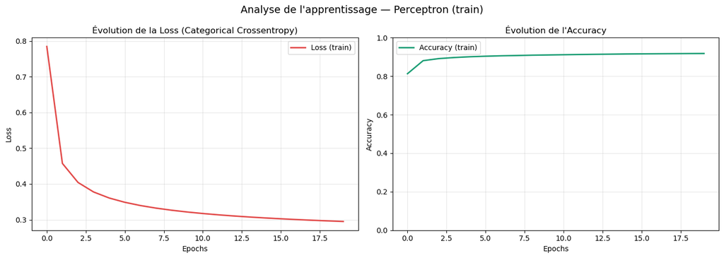

```
Loss finale     : 0.2950
Accuracy finale : 91.80%

╔══════════════════════════════════════════════════════════════╗
║              CONCEPTS CLÉS DE L'APPRENTISSAGE                ║
╠══════════════════════════════════════════════════════════════╣
║                                                              ║
║  BATCH SIZE = 32                                             ║
║  • 60 000 / 32 = 1 875 mises à jour de poids par epoch       ║
║  • Petit batch → gradient bruité mais meilleure généralisation║
║  • Grand batch → gradient stable mais risque d'overfitting   ║
║                                                              ║
║  EPOCHS = 20                                                 ║
║  • 1 epoch = le modèle voit 60 000 images une fois           ║
║  • Trop peu → sous-apprentissage                             ║
║  • Trop → sur-apprentissage (lire les courbes de val!)       ║
║                                                              ║
║  SGD (Descente de Gradient Stochastique)                     ║
║  • w ← w - lr × ∂Loss/∂w  (à chaque batch)                  ║
║  • lr=0.01 : pas de mise à jour ni trop grand ni trop petit  ║
║                                                              ║
╚══════════════════════════════════════════════════════════════╝
```

```python
# =============================================================================
# PARTIE 5 — Analyse de l'apprentissage
# =============================================================================

fig, axes = plt.subplots(1, 2, figsize=(14, 5))
fig.suptitle("Analyse de l'apprentissage — Perceptron (train)", fontsize=14)

# -----------------------------------------------------------------------------
# Courbe de Loss
# Une loss qui décroît régulièrement = apprentissage sain.
# Oscillations = lr trop grand ou batch trop petit.
# Plateau = lr trop petit ou modèle saturé.
# -----------------------------------------------------------------------------
axes[0].plot(history_perceptron.history['loss'],
             color='#E24B4A', linewidth=2, label='Loss (train)')
axes[0].set_title('Évolution de la Loss (Categorical Crossentropy)')
axes[0].set_xlabel('Epochs')
axes[0].set_ylabel('Loss')
axes[0].legend()
axes[0].grid(True, alpha=0.3)

# -----------------------------------------------------------------------------
# Courbe d'Accuracy
# Doit croître en miroir de la loss. Un découplage loss↑/acc↑ indiquerait
# un problème de calibration du modèle.
# -----------------------------------------------------------------------------
axes[1].plot(history_perceptron.history['accuracy'],
             color='#1D9E75', linewidth=2, label='Accuracy (train)')
axes[1].set_title("Évolution de l'Accuracy")
axes[1].set_xlabel('Epochs')
axes[1].set_ylabel('Accuracy')
axes[1].set_ylim(0, 1)
axes[1].legend()
axes[1].grid(True, alpha=0.3)

plt.tight_layout()
plt.show()

# Valeurs finales
print(f"Loss finale     : {history_perceptron.history['loss'][-1]:.4f}")
print(f"Accuracy finale : {history_perceptron.history['accuracy'][-1]*100:.2f}%")

# =============================================================================
# EXPLICATIONS DES CONCEPTS CLÉS
# =============================================================================
print("""
╔══════════════════════════════════════════════════════════════╗
║              CONCEPTS CLÉS DE L'APPRENTISSAGE                ║
╠══════════════════════════════════════════════════════════════╣
║                                                              ║
║  BATCH SIZE = 32                                             ║
║  • 60 000 / 32 = 1 875 mises à jour de poids par epoch       ║
║  • Petit batch → gradient bruité mais meilleure généralisation║
║  • Grand batch → gradient stable mais risque d'overfitting   ║
║                                                              ║
║  EPOCHS = 20                                                 ║
║  • 1 epoch = le modèle voit 60 000 images une fois           ║
║  • Trop peu → sous-apprentissage                             ║
║  • Trop → sur-apprentissage (lire les courbes de val!)       ║
║                                                              ║
║  SGD (Descente de Gradient Stochastique)                     ║
║  • w ← w - lr × ∂Loss/∂w  (à chaque batch)                  ║
║  • lr=0.01 : pas de mise à jour ni trop grand ni trop petit  ║
║                                                              ║
╚══════════════════════════════════════════════════════════════╝
""")
```

## Partie 6 — Validation et Visualisation

> **Objectif :** Détecter le sur-apprentissage (overfitting) et le sous-apprentissage (underfitting)  
> en comparant les courbes train vs validation.  
> La validation split permet de surveiller la généralisation **pendant** l'entraînement,  
> sans toucher au test set.

```
>>> Entraînement avec validation...
1500/1500 ━━━━━━━━━━━━━━━━━━━━ 3s 2ms/step - accuracy: 0.8020 - loss: 0.8432 - val_accuracy: 0.8763 - val_loss: 0.5078
1500/1500 ━━━━━━━━━━━━━━━━━━━━ 2s 1ms/step - accuracy: 0.8749 - loss: 0.4891 - val_accuracy: 0.8906 - val_loss: 0.4184
1500/1500 ━━━━━━━━━━━━━━━━━━━━ 2s 1ms/step - accuracy: 0.8863 - loss: 0.4279 - val_accuracy: 0.8988 - val_loss: 0.3825
1500/1500 ━━━━━━━━━━━━━━━━━━━━ 1s 728us/step - accuracy: 0.8924 - loss: 0.3975 - val_accuracy: 0.9028 - val_loss: 0.3622
1500/1500 ━━━━━━━━━━━━━━━━━━━━ 1s 743us/step - accuracy: 0.8966 - loss: 0.3783 - val_accuracy: 0.9067 - val_loss: 0.3487
1500/1500 ━━━━━━━━━━━━━━━━━━━━ 1s 727us/step - accuracy: 0.8995 - loss: 0.3648 - val_accuracy: 0.9089 - val_loss: 0.3389
1500/1500 ━━━━━━━━━━━━━━━━━━━━ 1s 722us/step - accuracy: 0.9021 - loss: 0.3546 - val_accuracy: 0.9114 - val_loss: 0.3313
1500/1500 ━━━━━━━━━━━━━━━━━━━━ 1s 784us/step - accuracy: 0.9044 - loss: 0.3464 - val_accuracy: 0.9117 - val_loss: 0.3253
1500/1500 ━━━━━━━━━━━━━━━━━━━━ 1s 730us/step - accuracy: 0.9061 - loss: 0.3398 - val_accuracy: 0.9122 - val_loss: 0.3204
1500/1500 ━━━━━━━━━━━━━━━━━━━━ 1s 855us/step - accuracy: 0.9076 - loss: 0.3342 - val_accuracy: 0.9128 - val_loss: 0.3162
1500/1500 ━━━━━━━━━━━━━━━━━━━━ 1s 726us/step - accuracy: 0.9089 - loss: 0.3294 - val_accuracy: 0.9133 - val_loss: 0.3127
1500/1500 ━━━━━━━━━━━━━━━━━━━━ 1s 726us/step - accuracy: 0.9099 - loss: 0.3253 - val_accuracy: 0.9141 - val_loss: 0.3096
1500/1500 ━━━━━━━━━━━━━━━━━━━━ 1s 810us/step - accuracy: 0.9109 - loss: 0.3216 - val_accuracy: 0.9146 - val_loss: 0.3069
1500/1500 ━━━━━━━━━━━━━━━━━━━━ 1s 732us/step - accuracy: 0.9119 - loss: 0.3184 - val_accuracy: 0.9152 - val_loss: 0.3045
1500/1500 ━━━━━━━━━━━━━━━━━━━━ 1s 738us/step - accuracy: 0.9123 - loss: 0.3154 - val_accuracy: 0.9155 - val_loss: 0.3023
1500/1500 ━━━━━━━━━━━━━━━━━━━━ 1s 930us/step - accuracy: 0.9133 - loss: 0.3128 - val_accuracy: 0.9155 - val_loss: 0.3004
1500/1500 ━━━━━━━━━━━━━━━━━━━━ 1s 750us/step - accuracy: 0.9140 - loss: 0.3104 - val_accuracy: 0.9160 - val_loss: 0.2987
1500/1500 ━━━━━━━━━━━━━━━━━━━━ 1s 732us/step - accuracy: 0.9144 - loss: 0.3082 - val_accuracy: 0.9160 - val_loss: 0.2971
1500/1500 ━━━━━━━━━━━━━━━━━━━━ 1s 730us/step - accuracy: 0.9149 - loss: 0.3062 - val_accuracy: 0.9171 - val_loss: 0.2956
1500/1500 ━━━━━━━━━━━━━━━━━━━━ 1s 771us/step - accuracy: 0.9154 - loss: 0.3043 - val_accuracy: 0.9177 - val_loss: 0.2943
```

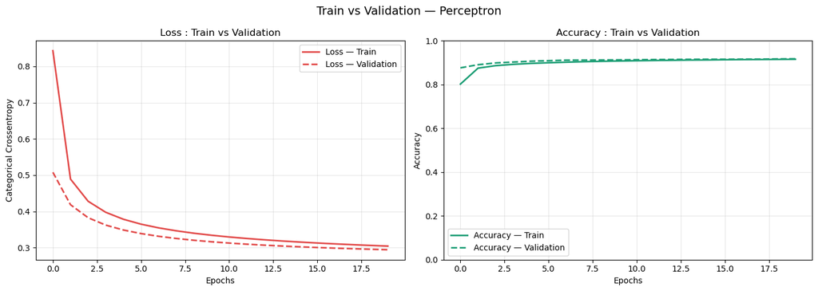

```
=== Diagnostic de généralisation ===
  Train Accuracy      : 91.54%
  Validation Accuracy : 91.77%
  Gap Train/Val       : -0.23%
  ✅ Bonne généralisation
```

```python
# =============================================================================
# PARTIE 6 — Validation et visualisation
# =============================================================================

# -----------------------------------------------------------------------------
# 1. Réentraînement avec validation_split=0.2
# Keras réserve les 20% derniers du train (12 000 images) pour la validation.
# Ces données ne sont JAMAIS utilisées pour mettre à jour les poids —
# elles servent uniquement à mesurer la généralisation à chaque epoch.
# -----------------------------------------------------------------------------
model_val = Sequential(name='Perceptron_Validation')
model_val.add(Dense(10, activation='softmax', input_shape=(784,)))
model_val.compile(
    loss='categorical_crossentropy',
    optimizer=SGD(learning_rate=0.01),
    metrics=['accuracy']
)

print('>>> Entraînement avec validation...')
history_val = model_val.fit(
    x_train_flat, y_train_ohe,
    epochs=20,
    batch_size=32,
    validation_split=0.2,   # 12 000 images réservées pour la validation
    verbose=1
)

# -----------------------------------------------------------------------------
# 2. Courbes Train vs Validation
# Lecture :
#   - Les deux courbes proches   → bonne généralisation
#   - Val_loss remonte           → overfitting détecté
#   - Les deux loss restent élevées → underfitting
# -----------------------------------------------------------------------------
fig, axes = plt.subplots(1, 2, figsize=(14, 5))
fig.suptitle('Train vs Validation — Perceptron', fontsize=14)

# Loss
axes[0].plot(history_val.history['loss'],
             color='#E24B4A', linewidth=2, label='Loss — Train')
axes[0].plot(history_val.history['val_loss'],
             color='#E24B4A', linewidth=2, linestyle='--', label='Loss — Validation')
axes[0].set_title('Loss : Train vs Validation')
axes[0].set_xlabel('Epochs')
axes[0].set_ylabel('Categorical Crossentropy')
axes[0].legend()
axes[0].grid(True, alpha=0.3)

# Accuracy
axes[1].plot(history_val.history['accuracy'],
             color='#1D9E75', linewidth=2, label='Accuracy — Train')
axes[1].plot(history_val.history['val_accuracy'],
             color='#1D9E75', linewidth=2, linestyle='--', label='Accuracy — Validation')
axes[1].set_title('Accuracy : Train vs Validation')
axes[1].set_xlabel('Epochs')
axes[1].set_ylabel('Accuracy')
axes[1].set_ylim(0, 1)
axes[1].legend()
axes[1].grid(True, alpha=0.3)

plt.tight_layout()
plt.show()

# -----------------------------------------------------------------------------
# 3. Diagnostic automatique
# Le gap train/val est l'indicateur clé de l'overfitting.
# Règle empirique : gap > 5% → overfitting à traiter (dropout, L2, early stopping)
# -----------------------------------------------------------------------------
train_acc_final = history_val.history['accuracy'][-1]
val_acc_final   = history_val.history['val_accuracy'][-1]
gap = (train_acc_final - val_acc_final) * 100

print('\n=== Diagnostic de généralisation ===')
print(f'  Train Accuracy      : {train_acc_final*100:.2f}%')
print(f'  Validation Accuracy : {val_acc_final*100:.2f}%')
print(f'  Gap Train/Val       : {gap:.2f}%')

if gap > 5:
    print('  ⚠️  Sur-apprentissage détecté → ajouter Dropout ou régularisation L2')
elif val_acc_final < 0.85:
    print('  ⚠️  Sous-apprentissage → augmenter la capacité du modèle ou les epochs')
else:
    print('  ✅ Bonne généralisation')
```

## Partie 7 — Optimisation des Hyperparamètres (Grid Search)

> **Objectif :** Trouver la combinaison optimale d'hyperparamètres de façon systématique.  
> Le Grid Search avec validation croisée (k-fold) garantit que les résultats ne dépendent  
> pas d'un split particulier — c'est la méthode rigoureuse de sélection de modèle.

```
>>> Lancement du Grid Search...
Fitting 3 folds for each of 27 candidates, totalling 81 fits

=== Meilleure configuration ===
  Accuracy moyenne : 91.11%
  Paramètres       : {'batch_size': 32, 'epochs': 20, 'model__learning_rate': 0.1}

=== Top 5 combinaisons ===
  91.11% (±0.99%)  →  {'batch_size': 32, 'epochs': 20, 'model__learning_rate': 0.1}
  91.07% (±0.97%)  →  {'batch_size': 32, 'epochs': 30, 'model__learning_rate': 0.1}
  91.06% (±0.87%)  →  {'batch_size': 64, 'epochs': 30, 'model__learning_rate': 0.1}
  90.74% (±0.84%)  →  {'batch_size': 64, 'epochs': 20, 'model__learning_rate': 0.1}
  90.69% (±0.80%)  →  {'batch_size': 128, 'epochs': 30, 'model__learning_rate': 0.1}
```

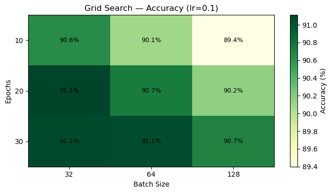

```python
# =============================================================================
# PARTIE 7 — Grid Search des hyperparamètres
# =============================================================================

# -----------------------------------------------------------------------------
# 1. Fonction de création du modèle
# GridSearchCV (scikit-learn) nécessite une fonction de fabrication du modèle,
# pas une instance directe. scikeras.KerasClassifier fait le pont Keras/sklearn.
# -----------------------------------------------------------------------------

def create_model_gs(learning_rate=0.01):
    m = Sequential()
    m.add(Dense(10, activation='softmax', input_shape=(784,)))
    m.compile(
        loss='sparse_categorical_crossentropy',  # ✅ accepte labels entiers
        optimizer=SGD(learning_rate=learning_rate),
        metrics=['accuracy']
    )
    return m

# Wrapper scikit-learn
model_gs = KerasClassifier(model=create_model_gs, verbose=0)

# Grille d'hyperparamètres
param_grid = {
    'epochs'               : [10, 20, 30],
    'batch_size'           : [32, 64, 128],
    'model__learning_rate' : [0.001, 0.01, 0.1]
}

# Sous-ensemble pour limiter le temps de calcul
x_gs = x_train_flat[:10000]
y_gs = y_train[:10000]   # ✅ labels entiers (0-9), PAS de OHE

# Grid Search avec validation croisée (cv=3)
print('>>> Lancement du Grid Search...')
grid_search = GridSearchCV(
    estimator=model_gs,
    param_grid=param_grid,
    cv=3,
    scoring='accuracy',
    n_jobs=1,
    verbose=1
)
grid_result = grid_search.fit(x_gs, y_gs)

# Résultats
print(f'\n=== Meilleure configuration ===')
print(f'  Accuracy moyenne : {grid_result.best_score_*100:.2f}%')
print(f'  Paramètres       : {grid_result.best_params_}')

print('\n=== Top 5 combinaisons ===')
means  = grid_result.cv_results_['mean_test_score']
stds   = grid_result.cv_results_['std_test_score']
params = grid_result.cv_results_['params']
results = sorted(zip(means, stds, params), reverse=True)
for mean, std, param in results[:5]:
    print(f'  {mean*100:.2f}% (±{std*100:.2f}%)  →  {param}')

# Heatmap
import pandas as pd
best_lr = grid_result.best_params_['model__learning_rate']
rows = [
    {'epochs': p['epochs'], 'batch_size': p['batch_size'], 'accuracy': m * 100}
    for m, s, p in zip(means, stds, params)
    if p['model__learning_rate'] == best_lr
]
df_heatmap = pd.DataFrame(rows).pivot(
    index='epochs', columns='batch_size', values='accuracy'
)

plt.figure(figsize=(7, 4))
im = plt.imshow(df_heatmap.values, cmap='YlGn', aspect='auto')
plt.colorbar(im, label='Accuracy (%)')
plt.xticks(range(len(df_heatmap.columns)), df_heatmap.columns)
plt.yticks(range(len(df_heatmap.index)),   df_heatmap.index)
plt.xlabel('Batch Size')
plt.ylabel('Epochs')
plt.title(f'Grid Search — Accuracy (lr={best_lr})')
for i in range(len(df_heatmap.index)):
    for j in range(len(df_heatmap.columns)):
        plt.text(j, i, f"{df_heatmap.values[i,j]:.1f}%",
                 ha='center', va='center', fontsize=9)
plt.tight_layout()
plt.show()
```

## Partie 8 — Sauvegarde et Chargement du Modèle

> **Objectif :** Persister un modèle entraîné pour réutilisation future.  
> En production, un modèle est entraîné une fois et servi des millions de fois —  
> la sauvegarde est donc une étape critique du pipeline MLOps.

```python
# =============================================================================
# PARTIE 8 — Sauvegarde et chargement du modèle
# =============================================================================

# -----------------------------------------------------------------------------
# 1. Sauvegarde complète au format .keras (recommandé depuis Keras 3)
# Ce format SavedModel sauvegarde :
#   - L'architecture (graph computationnel)
#   - Les poids entraînés
#   - La configuration de l'optimiseur (état des moments Adam, etc.)
# → Permet de reprendre l'entraînement exactement là où il s'est arrêté.
# -----------------------------------------------------------------------------
model_perceptron.save('modele_perceptron.keras')
print('✅ Modèle sauvegardé → modele_perceptron.keras')

# Alternative legacy HDF5 (.h5) — conservée pour compatibilité TF1/TF2
# model_perceptron.save('modele_perceptron.h5')

# -----------------------------------------------------------------------------
# 2. Chargement du modèle
# load_model reconstruit exactement le même modèle en mémoire.
# -----------------------------------------------------------------------------
model_charge = load_model('modele_perceptron.keras')
print('✅ Modèle rechargé avec succès')
model_charge.summary()

# -----------------------------------------------------------------------------
# 3. Vérification d'intégrité : les prédictions doivent être identiques
# np.allclose tolère de petites différences numériques (float32 vs float64).
# Si False → problème de sérialisation à investiguer.
# -----------------------------------------------------------------------------
pred_avant = model_perceptron.predict(x_test_flat[:5], verbose=0)
pred_apres = model_charge.predict(x_test_flat[:5], verbose=0)

print('\n=== Vérification d\'intégrité ===')
print(f'  Prédictions AVANT : {np.argmax(pred_avant, axis=1)}')
print(f'  Prédictions APRÈS : {np.argmax(pred_apres, axis=1)}')
print(f'  Identiques        : {np.allclose(pred_avant, pred_apres)} ✅')

# -----------------------------------------------------------------------------
# 4. Reprise de l'entraînement (fine-tuning / warm start)
# Utile pour : continuer l'entraînement avec de nouvelles données,
# ou affiner sur un domaine spécifique (transfer learning).
# -----------------------------------------------------------------------------
print('\n>>> Reprise de l\'entraînement (10 epochs supplémentaires)...')
model_charge.compile(
    loss='categorical_crossentropy',
    optimizer=SGD(learning_rate=0.01),
    metrics=['accuracy']
)
history_reprise = model_charge.fit(
    x_train_flat, y_train_ohe,
    epochs=10,
    batch_size=32,
    validation_split=0.2,
    verbose=1
)

loss_f, acc_f = model_charge.evaluate(x_test_flat, y_test_ohe, verbose=0)
print(f'\n  Accuracy après reprise : {acc_f*100:.2f}%')

# -----------------------------------------------------------------------------
# 5. Sauvegarde des poids uniquement (optionnel)
# Utile quand l'architecture est définie dans le code et qu'on veut
# sauvegarder uniquement les paramètres appris (fichier plus léger).
# -----------------------------------------------------------------------------
model_perceptron.save_weights('poids_perceptron.weights.h5')
print('\n✅ Poids sauvegardés → poids_perceptron.weights.h5')

# Rechargement dans un modèle vierge de même architecture
model_vide = Sequential()
model_vide.add(Dense(10, activation='softmax', input_shape=(784,)))
model_vide.compile(loss='categorical_crossentropy',
                   optimizer=SGD(learning_rate=0.01), metrics=['accuracy'])
model_vide.load_weights('poids_perceptron.weights.h5')

_, acc_v = model_vide.evaluate(x_test_flat, y_test_ohe, verbose=0)
print(f'  Accuracy après rechargement des poids : {acc_v*100:.2f}%  ✅')
```

```
✅ Modèle sauvegardé → modele_perceptron.keras
✅ Modèle rechargé avec succès
```

```
Model: "Perceptron_Multiclasses"
```

```
┏━━━━━━━━━━━━━━━━━━━━━━━━━━━━━━━━━┳━━━━━━━━━━━━━━━━━━━━━━━━┳━━━━━━━━━━━━━━━┓
┃ Layer (type)                    ┃ Output Shape           ┃       Param # ┃
┡━━━━━━━━━━━━━━━━━━━━━━━━━━━━━━━━━╇━━━━━━━━━━━━━━━━━━━━━━━━╇━━━━━━━━━━━━━━━┩
│ dense (Dense)                   │ (None, 10)             │         7,850 │
└─────────────────────────────────┴────────────────────────┴───────────────┘
```

```
 Total params: 7,852 (30.68 KB)
```

```
 Trainable params: 7,850 (30.66 KB)
```

```
 Non-trainable params: 0 (0.00 B)
```

```
 Optimizer params: 2 (12.00 B)
```

```
=== Vérification d'intégrité ===
  Prédictions AVANT : [7 2 1 0 4]
  Prédictions APRÈS : [7 2 1 0 4]
  Identiques        : True ✅

>>> Reprise de l'entraînement (10 epochs supplémentaires)...
1500/1500 ━━━━━━━━━━━━━━━━━━━━ 2s 1ms/step - accuracy: 0.9169 - loss: 0.2981 - val_accuracy: 0.9237 - val_loss: 0.2755
1500/1500 ━━━━━━━━━━━━━━━━━━━━ 2s 1ms/step - accuracy: 0.9174 - loss: 0.2966 - val_accuracy: 0.9235 - val_loss: 0.2756
1500/1500 ━━━━━━━━━━━━━━━━━━━━ 2s 1ms/step - accuracy: 0.9177 - loss: 0.2953 - val_accuracy: 0.9237 - val_loss: 0.2756
1500/1500 ━━━━━━━━━━━━━━━━━━━━ 1s 976us/step - accuracy: 0.9179 - loss: 0.2941 - val_accuracy: 0.9233 - val_loss: 0.2754
1500/1500 ━━━━━━━━━━━━━━━━━━━━ 1s 806us/step - accuracy: 0.9181 - loss: 0.2930 - val_accuracy: 0.9234 - val_loss: 0.2752
1500/1500 ━━━━━━━━━━━━━━━━━━━━ 1s 979us/step - accuracy: 0.9183 - loss: 0.2919 - val_accuracy: 0.9235 - val_loss: 0.2750
1500/1500 ━━━━━━━━━━━━━━━━━━━━ 1s 749us/step - accuracy: 0.9187 - loss: 0.2909 - val_accuracy: 0.9237 - val_loss: 0.2747
1500/1500 ━━━━━━━━━━━━━━━━━━━━ 1s 743us/step - accuracy: 0.9189 - loss: 0.2899 - val_accuracy: 0.9237 - val_loss: 0.2745
1500/1500 ━━━━━━━━━━━━━━━━━━━━ 1s 813us/step - accuracy: 0.9192 - loss: 0.2890 - val_accuracy: 0.9237 - val_loss: 0.2742
1500/1500 ━━━━━━━━━━━━━━━━━━━━ 1s 747us/step - accuracy: 0.9196 - loss: 0.2881 - val_accuracy: 0.9237 - val_loss: 0.2740

  Accuracy après reprise : 92.04%

✅ Poids sauvegardés → poids_perceptron.weights.h5
  Accuracy après rechargement des poids : 91.82%  ✅
```

## Partie 9 — Réseau de Neurones Multicouches (MLP)

> **Objectif :** Introduire une couche cachée pour apprendre des représentations non-linéaires.  
> La couche cachée + activation ReLU permet au réseau de modéliser des frontières de décision  
> arbitrairement complexes (théorème d'approximation universelle).

```
Model: "MLP_1_couche_cachee"
```

```
┏━━━━━━━━━━━━━━━━━━━━━━━━━━━━━━━━━┳━━━━━━━━━━━━━━━━━━━━━━━━┳━━━━━━━━━━━━━━━┓
┃ Layer (type)                    ┃ Output Shape           ┃       Param # ┃
┡━━━━━━━━━━━━━━━━━━━━━━━━━━━━━━━━━╇━━━━━━━━━━━━━━━━━━━━━━━━╇━━━━━━━━━━━━━━━┩
│ dense_166 (Dense)               │ (None, 100)            │        78,500 │
├─────────────────────────────────┼────────────────────────┼───────────────┤
│ dense_167 (Dense)               │ (None, 10)             │         1,010 │
└─────────────────────────────────┴────────────────────────┴───────────────┘
```

```
 Total params: 79,510 (310.59 KB)
```

```
 Trainable params: 79,510 (310.59 KB)
```

```
 Non-trainable params: 0 (0.00 B)
```

```
>>> Entraînement du MLP (1 couche cachée)...
1500/1500 ━━━━━━━━━━━━━━━━━━━━ 2s 1ms/step - accuracy: 0.8185 - loss: 0.7240 - val_accuracy: 0.8988 - val_loss: 0.3835
1500/1500 ━━━━━━━━━━━━━━━━━━━━ 2s 1ms/step - accuracy: 0.8977 - loss: 0.3696 - val_accuracy: 0.9128 - val_loss: 0.3137
1500/1500 ━━━━━━━━━━━━━━━━━━━━ 2s 1ms/step - accuracy: 0.9102 - loss: 0.3174 - val_accuracy: 0.9201 - val_loss: 0.2824
1500/1500 ━━━━━━━━━━━━━━━━━━━━ 2s 1ms/step - accuracy: 0.9193 - loss: 0.2871 - val_accuracy: 0.9254 - val_loss: 0.2606
1500/1500 ━━━━━━━━━━━━━━━━━━━━ 2s 1ms/step - accuracy: 0.9255 - loss: 0.2641 - val_accuracy: 0.9304 - val_loss: 0.2430
1500/1500 ━━━━━━━━━━━━━━━━━━━━ 1s 975us/step - accuracy: 0.9308 - loss: 0.2450 - val_accuracy: 0.9355 - val_loss: 0.2282
1500/1500 ━━━━━━━━━━━━━━━━━━━━ 2s 1ms/step - accuracy: 0.9356 - loss: 0.2286 - val_accuracy: 0.9391 - val_loss: 0.2154
1500/1500 ━━━━━━━━━━━━━━━━━━━━ 2s 1ms/step - accuracy: 0.9393 - loss: 0.2142 - val_accuracy: 0.9434 - val_loss: 0.2044
1500/1500 ━━━━━━━━━━━━━━━━━━━━ 2s 990us/step - accuracy: 0.9429 - loss: 0.2017 - val_accuracy: 0.9457 - val_loss: 0.1949
1500/1500 ━━━━━━━━━━━━━━━━━━━━ 2s 1ms/step - accuracy: 0.9461 - loss: 0.1906 - val_accuracy: 0.9477 - val_loss: 0.1866
1500/1500 ━━━━━━━━━━━━━━━━━━━━ 3s 2ms/step - accuracy: 0.9489 - loss: 0.1808 - val_accuracy: 0.9496 - val_loss: 0.1792
1500/1500 ━━━━━━━━━━━━━━━━━━━━ 2s 1ms/step - accuracy: 0.9510 - loss: 0.1719 - val_accuracy: 0.9513 - val_loss: 0.1726
1500/1500 ━━━━━━━━━━━━━━━━━━━━ 2s 1ms/step - accuracy: 0.9533 - loss: 0.1640 - val_accuracy: 0.9528 - val_loss: 0.1667
1500/1500 ━━━━━━━━━━━━━━━━━━━━ 2s 1000us/step - accuracy: 0.9555 - loss: 0.1567 - val_accuracy: 0.9548 - val_loss: 0.1615
1500/1500 ━━━━━━━━━━━━━━━━━━━━ 2s 1ms/step - accuracy: 0.9578 - loss: 0.1501 - val_accuracy: 0.9560 - val_loss: 0.1568
1500/1500 ━━━━━━━━━━━━━━━━━━━━ 2s 1ms/step - accuracy: 0.9596 - loss: 0.1441 - val_accuracy: 0.9575 - val_loss: 0.1526
1500/1500 ━━━━━━━━━━━━━━━━━━━━ 2s 1ms/step - accuracy: 0.9611 - loss: 0.1386 - val_accuracy: 0.9589 - val_loss: 0.1487
1500/1500 ━━━━━━━━━━━━━━━━━━━━ 2s 1ms/step - accuracy: 0.9627 - loss: 0.1335 - val_accuracy: 0.9599 - val_loss: 0.1452
1500/1500 ━━━━━━━━━━━━━━━━━━━━ 2s 1ms/step - accuracy: 0.9639 - loss: 0.1289 - val_accuracy: 0.9607 - val_loss: 0.1420
1500/1500 ━━━━━━━━━━━━━━━━━━━━ 2s 1ms/step - accuracy: 0.9652 - loss: 0.1245 - val_accuracy: 0.9614 - val_loss: 0.1391

=== Comparaison Perceptron vs MLP ===
  Perceptron (7 850 params)  : 91.82%
  MLP 1 couche (79 510 params): 95.94%
  Gain                        : +4.12% ✅
```

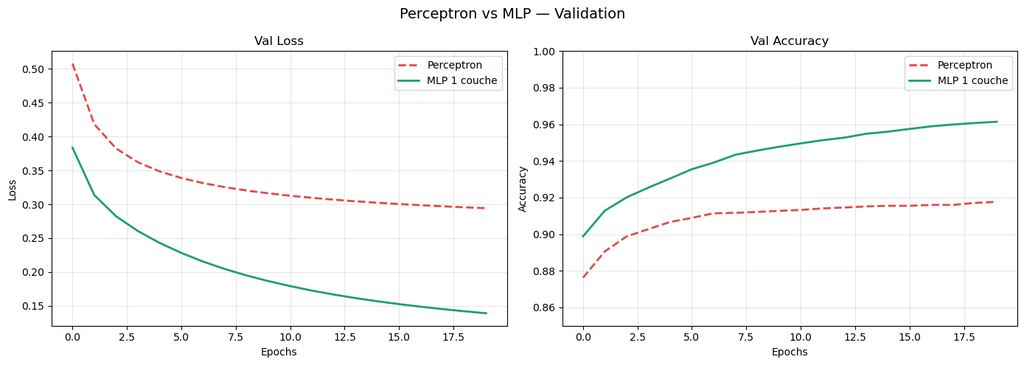

```python
# =============================================================================
# PARTIE 9 — MLP avec 1 couche cachée (100 neurones, ReLU)
# =============================================================================

# -----------------------------------------------------------------------------
# 1. Architecture : Input(784) → Dense(100, ReLU) → Dense(10, Softmax)
#
# Pourquoi ReLU ?
#   - ReLU(x) = max(0, x) : simple, rapide, non-saturante pour x > 0
#   - Évite le vanishing gradient (contrairement à sigmoid/tanh)
#   - Introduit la non-linéarité indispensable pour apprendre des patterns complexes
#
# Paramètres : (784×100 + 100) + (100×10 + 10) = 78 500 + 1 010 = 79 510
# Soit ~10× plus que le perceptron pour un gain attendu de +5 points d'accuracy.
# -----------------------------------------------------------------------------
model_mlp = Sequential(name='MLP_1_couche_cachee')
model_mlp.add(Dense(100, activation='relu', input_shape=(784,)))
model_mlp.add(Dense(10,  activation='softmax'))

model_mlp.summary()

# -----------------------------------------------------------------------------
# 2. Compilation — mêmes hyperparamètres que le perceptron pour comparaison équitable
# -----------------------------------------------------------------------------
model_mlp.compile(
    loss='categorical_crossentropy',
    optimizer=SGD(learning_rate=0.01),
    metrics=['accuracy']
)

# -----------------------------------------------------------------------------
# 3. Entraînement
# -----------------------------------------------------------------------------
print('>>> Entraînement du MLP (1 couche cachée)...')
history_mlp = model_mlp.fit(
    x_train_flat, y_train_ohe,
    epochs=20,
    batch_size=32,
    validation_split=0.2,
    verbose=1
)

# -----------------------------------------------------------------------------
# 4. Évaluation et comparaison avec le Perceptron
# -----------------------------------------------------------------------------
loss_mlp, acc_mlp = model_mlp.evaluate(x_test_flat, y_test_ohe, verbose=0)
loss_p2,  acc_p2  = model_perceptron.evaluate(x_test_flat, y_test_ohe, verbose=0)

print('\n=== Comparaison Perceptron vs MLP ===')
print(f'  Perceptron (7 850 params)  : {acc_p2*100:.2f}%')
print(f'  MLP 1 couche (79 510 params): {acc_mlp*100:.2f}%')
print(f'  Gain                        : +{(acc_mlp - acc_p2)*100:.2f}% ✅')

# Courbes comparatives
fig, axes = plt.subplots(1, 2, figsize=(14, 5))
fig.suptitle('Perceptron vs MLP — Validation', fontsize=14)

axes[0].plot(history_val.history['val_loss'],
             color='#E24B4A', linewidth=2, linestyle='--', label='Perceptron')
axes[0].plot(history_mlp.history['val_loss'],
             color='#1D9E75', linewidth=2, label='MLP 1 couche')
axes[0].set_title('Val Loss')
axes[0].set_xlabel('Epochs')
axes[0].set_ylabel('Loss')
axes[0].legend()
axes[0].grid(True, alpha=0.3)

axes[1].plot(history_val.history['val_accuracy'],
             color='#E24B4A', linewidth=2, linestyle='--', label='Perceptron')
axes[1].plot(history_mlp.history['val_accuracy'],
             color='#1D9E75', linewidth=2, label='MLP 1 couche')
axes[1].set_title('Val Accuracy')
axes[1].set_xlabel('Epochs')
axes[1].set_ylabel('Accuracy')
axes[1].set_ylim(0.85, 1.0)
axes[1].legend()
axes[1].grid(True, alpha=0.3)

plt.tight_layout()
plt.show()
```

```
=== Recherche de la taille optimale de couche cachée ===
  n=  32 | Test: 94.62% | Gap: -0.06% | Temps: 19.8s
  n=  64 | Test: 95.32% | Gap: -0.05% | Temps: 24.5s
  n= 100 | Test: 95.47% | Gap: 0.17% | Temps: 23.5s
  n= 128 | Test: 95.67% | Gap: 0.11% | Temps: 23.6s
  n= 256 | Test: 95.74% | Gap: 0.03% | Temps: 32.3s
  n= 512 | Test: 95.91% | Gap: 0.29% | Temps: 49.0s
```

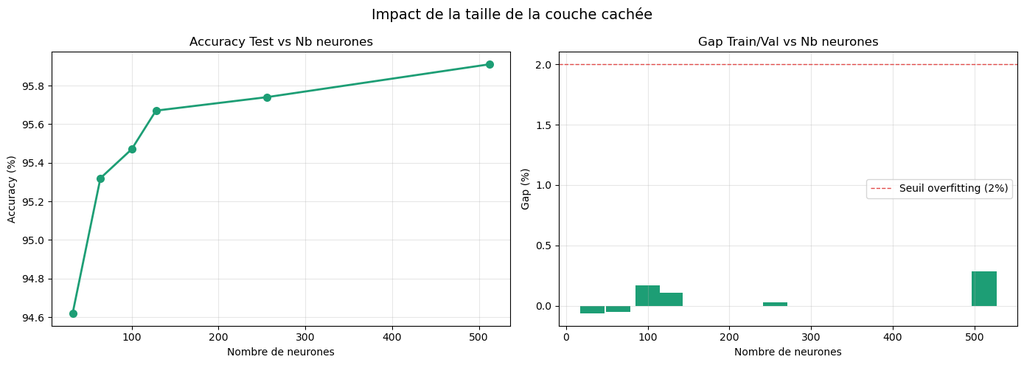

```
→ Taille optimale : 512 neurones (Test: 95.91%, Gap: 0.29%)
```

```python
# =============================================================================
# PARTIE 9 — Question : Taille optimale de la couche cachée
# Démarche expérimentale : tester plusieurs tailles et comparer
# accuracy test + gap train/val + temps d'entraînement.
# =============================================================================

tailles    = [32, 64, 100, 128, 256, 512]
resultats  = []

print('=== Recherche de la taille optimale de couche cachée ===')
for n in tailles:
    m = Sequential()
    m.add(Dense(n, activation='relu', input_shape=(784,)))
    m.add(Dense(10, activation='softmax'))
    m.compile(loss='categorical_crossentropy',
              optimizer=SGD(learning_rate=0.01), metrics=['accuracy'])

    start = time.time()
    hist  = m.fit(x_train_flat, y_train_ohe,
                  epochs=15, batch_size=32,
                  validation_split=0.2, verbose=0)
    duree = time.time() - start

    _, acc_test = m.evaluate(x_test_flat, y_test_ohe, verbose=0)
    val_acc     = hist.history['val_accuracy'][-1]
    train_acc   = hist.history['accuracy'][-1]
    gap         = train_acc - val_acc

    resultats.append({'neurones': n, 'test_acc': acc_test,
                      'gap': gap, 'duree': duree})
    print(f'  n={n:4d} | Test: {acc_test*100:.2f}% | '
          f'Gap: {gap*100:.2f}% | Temps: {duree:.1f}s')

# Visualisation
neurones  = [r['neurones']  for r in resultats]
test_accs = [r['test_acc']  for r in resultats]
gaps      = [r['gap']       for r in resultats]

fig, axes = plt.subplots(1, 2, figsize=(14, 5))
fig.suptitle('Impact de la taille de la couche cachée', fontsize=14)

axes[0].plot(neurones, [a*100 for a in test_accs],
             color='#1D9E75', linewidth=2, marker='o', markersize=7)
axes[0].set_title('Accuracy Test vs Nb neurones')
axes[0].set_xlabel('Nombre de neurones')
axes[0].set_ylabel('Accuracy (%)')
axes[0].grid(True, alpha=0.3)

couleurs_gap = ['#1D9E75' if g < 0.02 else '#E24B4A' for g in gaps]
axes[1].bar(neurones, [g*100 for g in gaps], color=couleurs_gap, width=30)
axes[1].axhline(y=2, color='#E24B4A', linestyle='--', linewidth=1,
                label='Seuil overfitting (2%)')
axes[1].set_title('Gap Train/Val vs Nb neurones')
axes[1].set_xlabel('Nombre de neurones')
axes[1].set_ylabel('Gap (%)')
axes[1].legend()
axes[1].grid(True, alpha=0.3)

plt.tight_layout()
plt.show()

# Conclusion
meilleur = max(resultats, key=lambda r: r['test_acc'])
print(f'\n→ Taille optimale : {meilleur["neurones"]} neurones '
      f'(Test: {meilleur["test_acc"]*100:.2f}%, Gap: {meilleur["gap"]*100:.2f}%)')
```

## Partie 10 — Réseau à Deux Couches Cachées

> **Objectif :** Mesurer l'impact de la profondeur du réseau.  
> Chaque couche supplémentaire permet d'apprendre des représentations de plus haut niveau —  
> mais au prix d'un temps d'entraînement plus long et d'un risque d'overfitting accru.

```
Model: "MLP_2_couches_cachees"
```

```
┏━━━━━━━━━━━━━━━━━━━━━━━━━━━━━━━━━┳━━━━━━━━━━━━━━━━━━━━━━━━┳━━━━━━━━━━━━━━━┓
┃ Layer (type)                    ┃ Output Shape           ┃       Param # ┃
┡━━━━━━━━━━━━━━━━━━━━━━━━━━━━━━━━━╇━━━━━━━━━━━━━━━━━━━━━━━━╇━━━━━━━━━━━━━━━┩
│ dense_180 (Dense)               │ (None, 300)            │       235,500 │
├─────────────────────────────────┼────────────────────────┼───────────────┤
│ dense_181 (Dense)               │ (None, 300)            │        90,300 │
├─────────────────────────────────┼────────────────────────┼───────────────┤
│ dense_182 (Dense)               │ (None, 10)             │         3,010 │
└─────────────────────────────────┴────────────────────────┴───────────────┘
```

```
 Total params: 328,810 (1.25 MB)
```

```
 Trainable params: 328,810 (1.25 MB)
```

```
 Non-trainable params: 0 (0.00 B)
```

```
>>> Entraînement du MLP (2 couches cachées)...
1500/1500 ━━━━━━━━━━━━━━━━━━━━ 6s 4ms/step - accuracy: 0.8289 - loss: 0.6697 - val_accuracy: 0.9090 - val_loss: 0.3199
1500/1500 ━━━━━━━━━━━━━━━━━━━━ 5s 3ms/step - accuracy: 0.9136 - loss: 0.3057 - val_accuracy: 0.9273 - val_loss: 0.2544
1500/1500 ━━━━━━━━━━━━━━━━━━━━ 5s 3ms/step - accuracy: 0.9284 - loss: 0.2515 - val_accuracy: 0.9369 - val_loss: 0.2205
1500/1500 ━━━━━━━━━━━━━━━━━━━━ 5s 4ms/step - accuracy: 0.9382 - loss: 0.2173 - val_accuracy: 0.9448 - val_loss: 0.1966
1500/1500 ━━━━━━━━━━━━━━━━━━━━ 5s 3ms/step - accuracy: 0.9449 - loss: 0.1915 - val_accuracy: 0.9504 - val_loss: 0.1782
1500/1500 ━━━━━━━━━━━━━━━━━━━━ 4s 3ms/step - accuracy: 0.9511 - loss: 0.1707 - val_accuracy: 0.9553 - val_loss: 0.1636
1500/1500 ━━━━━━━━━━━━━━━━━━━━ 4s 3ms/step - accuracy: 0.9560 - loss: 0.1537 - val_accuracy: 0.9582 - val_loss: 0.1518
1500/1500 ━━━━━━━━━━━━━━━━━━━━ 3s 2ms/step - accuracy: 0.9604 - loss: 0.1393 - val_accuracy: 0.9612 - val_loss: 0.1423
1500/1500 ━━━━━━━━━━━━━━━━━━━━ 3s 2ms/step - accuracy: 0.9644 - loss: 0.1272 - val_accuracy: 0.9634 - val_loss: 0.1345
1500/1500 ━━━━━━━━━━━━━━━━━━━━ 4s 2ms/step - accuracy: 0.9672 - loss: 0.1168 - val_accuracy: 0.9645 - val_loss: 0.1281
1500/1500 ━━━━━━━━━━━━━━━━━━━━ 3s 2ms/step - accuracy: 0.9700 - loss: 0.1077 - val_accuracy: 0.9664 - val_loss: 0.1227
1500/1500 ━━━━━━━━━━━━━━━━━━━━ 3s 2ms/step - accuracy: 0.9725 - loss: 0.0998 - val_accuracy: 0.9672 - val_loss: 0.1181
1500/1500 ━━━━━━━━━━━━━━━━━━━━ 4s 3ms/step - accuracy: 0.9743 - loss: 0.0927 - val_accuracy: 0.9682 - val_loss: 0.1140
1500/1500 ━━━━━━━━━━━━━━━━━━━━ 5s 3ms/step - accuracy: 0.9762 - loss: 0.0864 - val_accuracy: 0.9691 - val_loss: 0.1106
1500/1500 ━━━━━━━━━━━━━━━━━━━━ 5s 3ms/step - accuracy: 0.9781 - loss: 0.0807 - val_accuracy: 0.9700 - val_loss: 0.1075
1500/1500 ━━━━━━━━━━━━━━━━━━━━ 4s 3ms/step - accuracy: 0.9798 - loss: 0.0755 - val_accuracy: 0.9704 - val_loss: 0.1048
1500/1500 ━━━━━━━━━━━━━━━━━━━━ 4s 3ms/step - accuracy: 0.9812 - loss: 0.0708 - val_accuracy: 0.9709 - val_loss: 0.1023
1500/1500 ━━━━━━━━━━━━━━━━━━━━ 4s 3ms/step - accuracy: 0.9825 - loss: 0.0664 - val_accuracy: 0.9712 - val_loss: 0.1002
1500/1500 ━━━━━━━━━━━━━━━━━━━━ 4s 3ms/step - accuracy: 0.9836 - loss: 0.0624 - val_accuracy: 0.9718 - val_loss: 0.0982
1500/1500 ━━━━━━━━━━━━━━━━━━━━ 5s 3ms/step - accuracy: 0.9847 - loss: 0.0587 - val_accuracy: 0.9722 - val_loss: 0.0966

====================================================================
  Modèle                           Params   Accuracy  Temps (s)
====================================================================
  Perceptron                        7 850     91.82%         N/A
  MLP 1 couche (100)               79 510     95.94%         N/A
  MLP 2 couches (300)             328 810     97.27%       85.4s
====================================================================
  → Gain MLP2 vs Perceptron : +5.45%
  → Gain MLP2 vs MLP1       : +1.33% (pour 4× plus de paramètres — rendement décroissant)
```

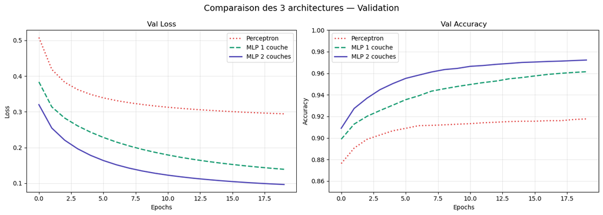

```python
# =============================================================================
# PARTIE 10 — MLP avec 2 couches cachées (300 neurones chacune)
# =============================================================================

# -----------------------------------------------------------------------------
# 1. Architecture : Input(784) → Dense(300,ReLU) → Dense(300,ReLU) → Dense(10,Softmax)
#
# Paramètres :
#   Couche 1 : 784×300 + 300 = 235 500
#   Couche 2 : 300×300 + 300 = 90 300
#   Sortie   : 300×10  + 10  = 3 010
#   TOTAL    : 328 810 paramètres (~4× plus que le MLP 1 couche)
# -----------------------------------------------------------------------------
model_deep = Sequential(name='MLP_2_couches_cachees')
model_deep.add(Dense(300, activation='relu', input_shape=(784,)))
model_deep.add(Dense(300, activation='relu'))
model_deep.add(Dense(10,  activation='softmax'))

model_deep.summary()

# -----------------------------------------------------------------------------
# 2. Compilation
# -----------------------------------------------------------------------------
model_deep.compile(
    loss='categorical_crossentropy',
    optimizer=SGD(learning_rate=0.01),
    metrics=['accuracy']
)

# -----------------------------------------------------------------------------
# 3. Entraînement + mesure du temps
# Mesurer le temps d'entraînement est important pour évaluer le coût
# computationnel d'une architecture plus profonde.
# -----------------------------------------------------------------------------
print('>>> Entraînement du MLP (2 couches cachées)...')
start = time.time()
history_deep = model_deep.fit(
    x_train_flat, y_train_ohe,
    epochs=20,
    batch_size=32,
    validation_split=0.2,
    verbose=1
)
temps_deep = time.time() - start

loss_deep, acc_deep = model_deep.evaluate(x_test_flat, y_test_ohe, verbose=0)

# -----------------------------------------------------------------------------
# 4. Tableau comparatif final — les 3 architectures
# -----------------------------------------------------------------------------
loss_p3,   acc_p3   = model_perceptron.evaluate(x_test_flat, y_test_ohe, verbose=0)
loss_mlp3, acc_mlp3 = model_mlp.evaluate(x_test_flat, y_test_ohe, verbose=0)

print('\n' + '='*68)
print(f'  {"Modèle":<28} {"Params":>10} {"Accuracy":>10} {"Temps (s)":>10}')
print('='*68)
print(f'  {"Perceptron":<28} {"7 850":>10} {acc_p3*100:>9.2f}%  {"N/A":>10}')
print(f'  {"MLP 1 couche (100)":<28} {"79 510":>10} {acc_mlp3*100:>9.2f}%  {"N/A":>10}')
print(f'  {"MLP 2 couches (300)":<28} {"328 810":>10} {acc_deep*100:>9.2f}%  {temps_deep:>9.1f}s')
print('='*68)
print(f'  → Gain MLP2 vs Perceptron : +{(acc_deep-acc_p3)*100:.2f}%')
print(f'  → Gain MLP2 vs MLP1       : +{(acc_deep-acc_mlp3)*100:.2f}% '
      f'(pour 4× plus de paramètres — rendement décroissant)')

# -----------------------------------------------------------------------------
# 5. Comparaison des 3 courbes de validation
# -----------------------------------------------------------------------------
fig, axes = plt.subplots(1, 2, figsize=(14, 5))
fig.suptitle('Comparaison des 3 architectures — Validation', fontsize=14)

for hist, label, color, ls in [
    (history_val,  'Perceptron',     '#E24B4A', ':'),
    (history_mlp,  'MLP 1 couche',   '#1D9E75', '--'),
    (history_deep, 'MLP 2 couches',  '#534AB7', '-')
]:
    axes[0].plot(hist.history['val_loss'],
                 color=color, linewidth=2, linestyle=ls, label=label)
    axes[1].plot(hist.history['val_accuracy'],
                 color=color, linewidth=2, linestyle=ls, label=label)

axes[0].set_title('Val Loss')
axes[0].set_xlabel('Epochs')
axes[0].set_ylabel('Loss')
axes[0].legend()
axes[0].grid(True, alpha=0.3)

axes[1].set_title('Val Accuracy')
axes[1].set_xlabel('Epochs')
axes[1].set_ylabel('Accuracy')
axes[1].set_ylim(0.85, 1.0)
axes[1].legend()
axes[1].grid(True, alpha=0.3)

plt.tight_layout()
plt.show()
```

## Question Supplémentaire 1 — Impact des Hyperparamètres

> **Objectif :** Analyser l'effet du learning rate et du batch size sur la vitesse de convergence, la stabilité et la performance finale.  
> Ces deux hyperparamètres sont les leviers les plus impactants en pratique.

```
=== Expérience 1 : Impact du Learning Rate (batch=32) ===
  lr=0.001 | Acc: 91.30% | Stabilité (std 5 last): 0.167% | Temps: 33.8s
  lr=0.010 | Acc: 96.09% | Stabilité (std 5 last): 0.139% | Temps: 29.0s
  lr=0.100 | Acc: 97.68% | Stabilité (std 5 last): 0.037% | Temps: 29.2s

=== Expérience 2 : Impact du Batch Size (lr=0.01) ===
  batch= 16 | Acc: 97.37% | Stabilité: 0.121% | Temps: 50.1s
  batch= 32 | Acc: 96.15% | Stabilité: 0.160% | Temps: 29.6s
  batch=128 | Acc: 93.24% | Stabilité: 0.219% | Temps: 14.3s
```

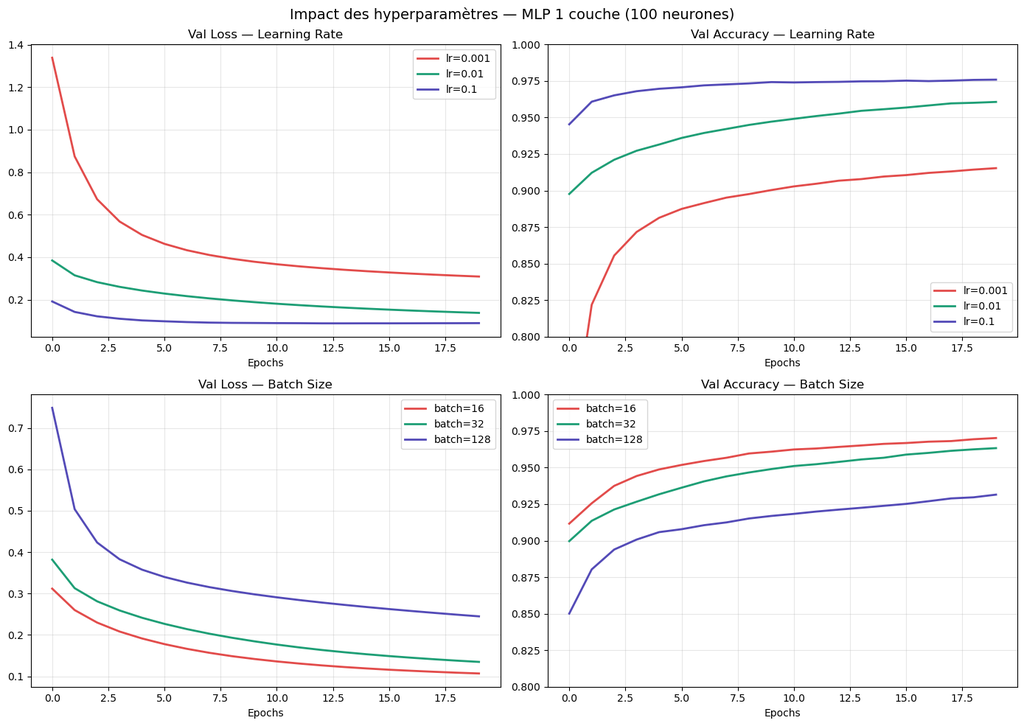

```
=================================================================
  Configuration            Accuracy  Temps (s)    Stabilité
=================================================================
  lr=0.001                   91.30%      33.8s      0.167%
  lr=0.01                    96.09%      29.0s      0.139%
  lr=0.1                     97.68%      29.2s      0.037%
-----------------------------------------------------------------
  batch=16                   97.37%      50.1s      0.121%
  batch=32                   96.15%      29.6s      0.160%
  batch=128                  93.24%      14.3s      0.219%
=================================================================
```

```python
# =============================================================================
# QUESTION SUPP. 1 — Impact du learning rate et du batch size
# Modèle testé : MLP 1 couche cachée (100 neurones)
# Protocole : on fait varier UN seul paramètre à la fois (ceteris paribus)
# pour isoler son effet — principe fondamental d'expérimentation contrôlée.
# =============================================================================

def build_mlp_100():
    """Fabrique un MLP standard à 1 couche cachée de 100 neurones."""
    m = Sequential()
    m.add(Dense(100, activation='relu', input_shape=(784,)))
    m.add(Dense(10,  activation='softmax'))
    return m

# -----------------------------------------------------------------------------
# Expérience 1 : Impact du Learning Rate (batch fixe = 32)
# Hypothèses :
#   lr=0.001 → convergence lente mais stable
#   lr=0.01  → équilibre vitesse/stabilité (valeur par défaut SGD)
#   lr=0.1   → convergence rapide mais risque d'osciller / diverger
# -----------------------------------------------------------------------------
learning_rates = [0.001, 0.01, 0.1]
resultats_lr   = {}

print('=== Expérience 1 : Impact du Learning Rate (batch=32) ===')
for lr in learning_rates:
    m = build_mlp_100()
    m.compile(loss='categorical_crossentropy',
              optimizer=SGD(learning_rate=lr), metrics=['accuracy'])

    start = time.time()
    hist  = m.fit(x_train_flat, y_train_ohe,
                  epochs=20, batch_size=32,
                  validation_split=0.2, verbose=0)
    duree = time.time() - start

    _, acc = m.evaluate(x_test_flat, y_test_ohe, verbose=0)
    stabilite = np.std(hist.history['val_accuracy'][-5:]) * 100
    resultats_lr[lr] = {'history': hist, 'acc': acc,
                        'duree': duree, 'stabilite': stabilite}
    print(f'  lr={lr:.3f} | Acc: {acc*100:.2f}% | '
          f'Stabilité (std 5 last): {stabilite:.3f}% | Temps: {duree:.1f}s')

# -----------------------------------------------------------------------------
# Expérience 2 : Impact du Batch Size (lr fixe = 0.01)
# Hypothèses :
#   batch=16  → gradient bruité → meilleure généralisation mais plus lent
#   batch=32  → compromis idéal (standard dans la littérature)
#   batch=128 → gradient lissé → plus rapide mais risque d'overfitting
# -----------------------------------------------------------------------------
batch_sizes  = [16, 32, 128]
resultats_bs = {}

print('\n=== Expérience 2 : Impact du Batch Size (lr=0.01) ===')
for bs in batch_sizes:
    m = build_mlp_100()
    m.compile(loss='categorical_crossentropy',
              optimizer=SGD(learning_rate=0.01), metrics=['accuracy'])

    start = time.time()
    hist  = m.fit(x_train_flat, y_train_ohe,
                  epochs=20, batch_size=bs,
                  validation_split=0.2, verbose=0)
    duree = time.time() - start

    _, acc = m.evaluate(x_test_flat, y_test_ohe, verbose=0)
    stabilite = np.std(hist.history['val_accuracy'][-5:]) * 100
    resultats_bs[bs] = {'history': hist, 'acc': acc,
                        'duree': duree, 'stabilite': stabilite}
    print(f'  batch={bs:3d} | Acc: {acc*100:.2f}% | '
          f'Stabilité: {stabilite:.3f}% | Temps: {duree:.1f}s')

# -----------------------------------------------------------------------------
# Visualisation
# -----------------------------------------------------------------------------
couleurs = ['#E24B4A', '#1D9E75', '#534AB7']

fig, axes = plt.subplots(2, 2, figsize=(14, 10))
fig.suptitle('Impact des hyperparamètres — MLP 1 couche (100 neurones)', fontsize=14)

for (lr, color) in zip(learning_rates, couleurs):
    h = resultats_lr[lr]['history']
    axes[0,0].plot(h.history['val_loss'],     color=color, lw=2, label=f'lr={lr}')
    axes[0,1].plot(h.history['val_accuracy'], color=color, lw=2, label=f'lr={lr}')

for (bs, color) in zip(batch_sizes, couleurs):
    h = resultats_bs[bs]['history']
    axes[1,0].plot(h.history['val_loss'],     color=color, lw=2, label=f'batch={bs}')
    axes[1,1].plot(h.history['val_accuracy'], color=color, lw=2, label=f'batch={bs}')

titres = ['Val Loss — Learning Rate', 'Val Accuracy — Learning Rate',
          'Val Loss — Batch Size',    'Val Accuracy — Batch Size']
for ax, titre in zip(axes.flatten(), titres):
    ax.set_title(titre)
    ax.set_xlabel('Epochs')
    ax.legend()
    ax.grid(True, alpha=0.3)

axes[0,1].set_ylim(0.8, 1.0)
axes[1,1].set_ylim(0.8, 1.0)
plt.tight_layout()
plt.show()

# Tableau récapitulatif
print('\n' + '='*65)
print(f'  {"Configuration":<22} {"Accuracy":>10} {"Temps (s)":>10} {"Stabilité":>12}')
print('='*65)
for lr in learning_rates:
    r = resultats_lr[lr]
    print(f'  {"lr="+str(lr):<22} {r["acc"]*100:>9.2f}% '
          f'{r["duree"]:>9.1f}s  {r["stabilite"]:>9.3f}%')
print('-'*65)
for bs in batch_sizes:
    r = resultats_bs[bs]
    print(f'  {"batch="+str(bs):<22} {r["acc"]*100:>9.2f}% '
          f'{r["duree"]:>9.1f}s  {r["stabilite"]:>9.3f}%')
print('='*65)
```

## Question Supplémentaire 2 — Régularisation

> **Objectif :** Réduire l'overfitting et améliorer la généralisation avec deux techniques classiques :  
> **Dropout** (désactivation aléatoire de neurones) et **L2** (pénalisation des grands poids).  
> Ces techniques sont complémentaires : le Dropout agit sur la structure du réseau,  
> L2 agit sur la valeur des paramètres.

```
>>> Entraînement : Base (sans régul.)
  Test Accuracy : 96.09%  |  Gap train/val : 0.37%

>>> Entraînement : Dropout (p=0.3)
  Test Accuracy : 95.87%  |  Gap train/val : -0.99%

>>> Entraînement : L2 (λ=0.001)
  Test Accuracy : 95.90%  |  Gap train/val : 0.10%
```

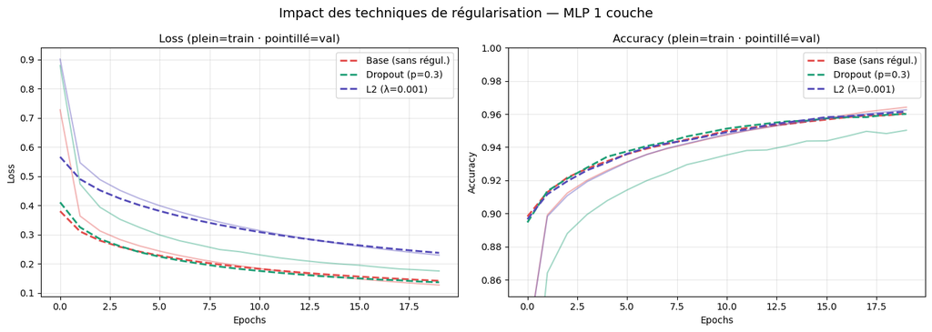

```
============================================================
  Modèle                   Test Acc   Gap Train/Val
============================================================
  Base (sans régul.)         96.09%          0.37%
  Dropout (p=0.3)            95.87%         -0.99%
  L2 (λ=0.001)               95.90%          0.10%
============================================================
```

```python
# =============================================================================
# QUESTION SUPP. 2 — Techniques de régularisation
# =============================================================================

# -----------------------------------------------------------------------------
# Modèle de référence (sans régularisation)
# Sert de baseline pour mesurer l'impact de chaque technique.
# -----------------------------------------------------------------------------
def build_base():
    m = Sequential(name='Base')
    m.add(Dense(100, activation='relu', input_shape=(784,)))
    m.add(Dense(10,  activation='softmax'))
    m.compile(loss='categorical_crossentropy',
              optimizer=SGD(learning_rate=0.01), metrics=['accuracy'])
    return m

# -----------------------------------------------------------------------------
# Méthode 1 — Dropout (p=0.3)
# À chaque batch, 30% des neurones de la couche cachée sont désactivés
# aléatoirement. Cela force le réseau à apprendre des représentations
# redondantes et distribuées, moins susceptibles d'overfitter.
# Dropout est inactif à l'inférence (predict) — les poids sont rescalés.
# Valeur p=0.3-0.5 est standard pour les couches denses.
# -----------------------------------------------------------------------------
def build_dropout():
    m = Sequential(name='Dropout_0.3')
    m.add(Dense(100, activation='relu', input_shape=(784,)))
    m.add(Dropout(0.3))   # 30% des neurones désactivés aléatoirement
    m.add(Dense(10,  activation='softmax'))
    m.compile(loss='categorical_crossentropy',
              optimizer=SGD(learning_rate=0.01), metrics=['accuracy'])
    return m

# -----------------------------------------------------------------------------
# Méthode 2 — Régularisation L2 (λ=0.001)
# Ajoute une pénalité λ×Σ(w²) à la loss totale.
# Cela force les poids à rester petits, réduisant la complexité effective
# du modèle et donc sa tendance à mémoriser les exemples d'entraînement.
# λ (lambda) contrôle l'intensité de la régularisation :
#   λ=0.001 → pénalité légère, peu invasive
#   λ=0.01  → pénalité modérée
#   λ=0.1   → pénalité forte (risque de sous-apprentissage)
# -----------------------------------------------------------------------------
def build_l2():
    m = Sequential(name='L2_0.001')
    m.add(Dense(100, activation='relu', input_shape=(784,),
                kernel_regularizer=l2(0.001)))
    m.add(Dense(10,  activation='softmax'))
    m.compile(loss='categorical_crossentropy',
              optimizer=SGD(learning_rate=0.01), metrics=['accuracy'])
    return m

# -----------------------------------------------------------------------------
# Entraînement des 3 configurations
# -----------------------------------------------------------------------------
configs = {
    'Base (sans régul.)': build_base(),
    'Dropout (p=0.3)'   : build_dropout(),
    'L2 (λ=0.001)'      : build_l2()
}

histories_q2 = {}
modeles_q2   = {}

for nom, modele in configs.items():
    print(f'\n>>> Entraînement : {nom}')
    hist = modele.fit(
        x_train_flat, y_train_ohe,
        epochs=20, batch_size=32,
        validation_split=0.2, verbose=0
    )
    histories_q2[nom] = hist
    modeles_q2[nom]   = modele

    _, acc  = modele.evaluate(x_test_flat, y_test_ohe, verbose=0)
    gap     = (hist.history['accuracy'][-1] - hist.history['val_accuracy'][-1]) * 100
    print(f'  Test Accuracy : {acc*100:.2f}%  |  Gap train/val : {gap:.2f}%')

# -----------------------------------------------------------------------------
# Visualisation
# Trait plein = train (plus facile à optimiser)
# Pointillé  = validation (le vrai indicateur de généralisation)
# On cherche : pointillé proche du plein → faible gap → bonne généralisation
# -----------------------------------------------------------------------------
couleurs = ['#E24B4A', '#1D9E75', '#534AB7']
fig, axes = plt.subplots(1, 2, figsize=(14, 5))
fig.suptitle('Impact des techniques de régularisation — MLP 1 couche', fontsize=14)

for (nom, hist), color in zip(histories_q2.items(), couleurs):
    axes[0].plot(hist.history['loss'],
                 color=color, lw=1.5, linestyle='-',  alpha=0.4)
    axes[0].plot(hist.history['val_loss'],
                 color=color, lw=2,   linestyle='--', label=nom)
    axes[1].plot(hist.history['accuracy'],
                 color=color, lw=1.5, linestyle='-',  alpha=0.4)
    axes[1].plot(hist.history['val_accuracy'],
                 color=color, lw=2,   linestyle='--', label=nom)

axes[0].set_title('Loss (plein=train · pointillé=val)')
axes[0].set_xlabel('Epochs')
axes[0].set_ylabel('Loss')
axes[0].legend()
axes[0].grid(True, alpha=0.3)

axes[1].set_title('Accuracy (plein=train · pointillé=val)')
axes[1].set_xlabel('Epochs')
axes[1].set_ylabel('Accuracy')
axes[1].set_ylim(0.85, 1.0)
axes[1].legend()
axes[1].grid(True, alpha=0.3)

plt.tight_layout()
plt.show()

# Tableau récapitulatif final
print('\n' + '='*60)
print(f'  {"Modèle":<22} {"Test Acc":>10} {"Gap Train/Val":>15}')
print('='*60)
for nom in histories_q2:
    hist   = histories_q2[nom]
    modele = modeles_q2[nom]
    _, acc = modele.evaluate(x_test_flat, y_test_ohe, verbose=0)
    gap    = (hist.history['accuracy'][-1] - hist.history['val_accuracy'][-1]) * 100
    print(f'  {nom:<22} {acc*100:>9.2f}%  {gap:>12.2f}%')
print('='*60)
```

## Conclusion Générale

[output not shown]

*Notebook réalisé avec TensorFlow/Keras — Dataset MNIST (LeCun et al., 1998)*